# Submission-1

## Ans 3 : No missing values in item , data , user data sets

#### 4. Find the number of movies per genre using the item data - 5 marks

```python
print('\n\033[1m The movies under each genre are : \033[0m \n')
print(item.iloc[:, 3:21].sum())
print('\033[1m Total is : \033[0m', item.iloc[:, 3:21].sum().sum())
```

```
 The movies under each genre are :

unknown          1
Action         251
Adventure      135
Animation       42
Childrens      122
Comedy         505
Crime          109
Documentary     50
Drama          725
Fantasy         22
Film-Noir       24
Horror          92
Musical         56
Mystery         61
Romance        247
Sci-Fi         101
Thriller       251
War             71
dtype: int64
 Total is :  2865
```

```python
### Second option to get count of movies genre wise
item_movies = item.iloc[:, 3:21].apply(pd.Series.value_counts)
item_movies.loc[1]
```

```
unknown          1
Action         251
Adventure      135
Animation       42
Childrens      122
Comedy         505
Crime          109
Documentary     50
Drama          725
Fantasy         22
Film-Noir       24
Horror          92
Musical         56
Mystery         61
Romance        247
Sci-Fi         101
Thriller       251
War             71
Name: 1, dtype: int64
```

#### 5. Find the movies that have more than one genre - 2.5 marks

```python
item1= pd.DataFrame(item.where((item.iloc[0:1681, 3:22].sum(axis=1))>1))
print('\n\033[1m Movies classified under >1 genre : \033[0m \n')
item1.dropna(inplace= True)
print(item1['movie title'])
```

```
 Movies classified under >1 genre :

0               Toy Story
1               GoldenEye
3              Get Shorty
4                 Copycat
6          Twelve Monkeys
               ...
1667    MURDER and murder
1668              Tainted
1671               Mirage
1677            B. Monkey
1678        Sliding Doors
Name: movie title, Length: 849, dtype: object
```

#### 6. Drop the movie where the genre is unknown - 2.5 marks

```python
item3 = item.copy()
##item3
item3.drop(columns='unknown', inplace=True)
print(item3)
```

```
      movie id                          movie title release date  Action  \
0            1                           Toy Story   01-Jan-1995       0
1            2                           GoldenEye   01-Jan-1995       1
2            3                          Four Rooms   01-Jan-1995       0
3            4                          Get Shorty   01-Jan-1995       1
4            5                             Copycat   01-Jan-1995       0
...        ...                                  ...          ...     ...
1676      1678                          Mat' i syn   06-Feb-1998       0
1677      1679                           B. Monkey   06-Feb-1998       0
1678      1680                       Sliding Doors   01-Jan-1998       0
1679      1681                        You So Crazy   01-Jan-1994       0
1680      1682  Scream of Stone (Schrei aus Stein)   08-Mar-1996       0

      Adventure  Animation  Childrens  Comedy  Crime  Documentary  Drama  \
0             0          1          1       1      0            0      0
```

[output cut: 38 more lines]

### 7. Univariate plots of columns: 'rating', 'Age', 'release year', 'Gender' and 'Occupation' - 10 marks

```python
# HINT: use distplot for age and countplot for gender,ratings,occupation.
# HINT: Please refer to the below snippet to understand how to get to release year from release date. You can use str.split()
# as depicted below
# Hint : Use displot without kde for release year or line plot showing year wise count.
```

```python
a = 'My*cat*is*brown'
print(a.split('*')[3])

#similarly, the release year needs to be taken out from release date

#also you can simply slice existing string to get the desired data, if we want to take out the colour of the cat

print(a[10:])
print(a[-5:])
```

```
brown
brown
brown
```

#### Univariate plot for Age

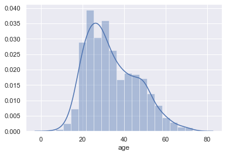

```python
plt.rcParams['patch.force_edgecolor'] = True
sns.distplot(user['age']);
```

#### Univariate plot for gender

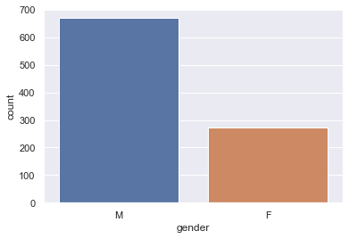

```python
sns.countplot(user['gender']);
```

#### Univariate plot for Rating

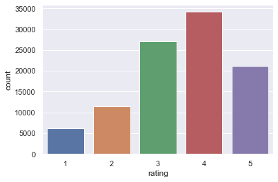

```python
sns.countplot(data['rating']);
```

#### Univariate plot for Occupation

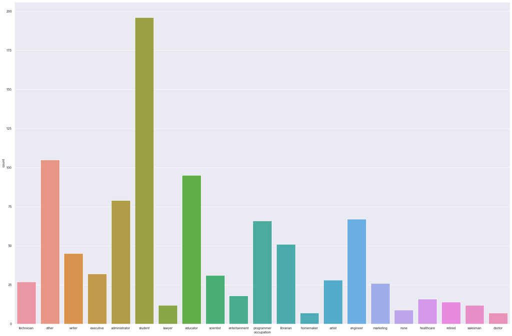

```python
plt.figure(figsize=(30,20))
sns.countplot(user['occupation']);
```

#### Univariate plot for Release Year

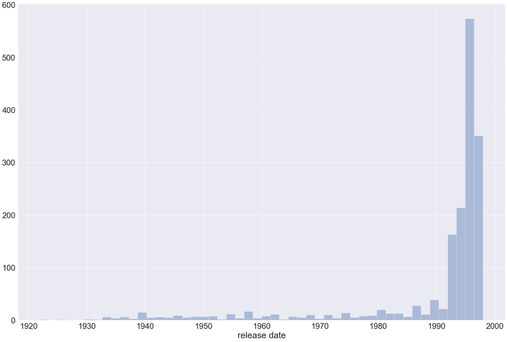

```python
item4 = pd.Series(item['release date'].str.split('-'))
#print(item4.str.get(2))
item4_Series = pd.Series(item4.str.get(2))
#print(item4_Series)

plt.figure(figsize=(30,20))
sns.distplot(item4.str.get(2), kde=False);  ### CORRECT
```

### 8. Visualize how popularity of genres has changed over the years - 10 marks

Note that you need to use the number of releases in a year as a parameter of popularity of a genre

Hint

1: you need to reach to a data frame where the release year is the index and the genre is the column names (one cell shows the number of release in a year in one genre) or vice versa. Once that is achieved, you can either use univariate plots or can use the heatmap to visualise all the changes over the years in one go.

Hint 2: Use groupby on the relevant column and use sum() on the same to find out the nuumber of releases in a year/genre.

```python
#Your answer here
item1= pd.DataFrame(item.where((item.iloc[0:1681, 3:22].sum(axis=1))>0))
item1.dropna(inplace= True)
##print(item1)
```

```python
item4 = pd.Series(item['release date'].str.split('-'))
##print(item4.str.get(2))
item4_Series = pd.Series(item4.str.get(2))
##print(item4_Series)
```

```python
pd.set_option('max_rows', None)
item4 = pd.Series(item['release date'].str.split('-'))
#print(item4.str.get(2))
item4_Series_A = pd.Series(item4.str.get(2), name='Year')
#print(item4_Series_A)
```

```python
pd.set_option('max_rows', None)
item6 = item.copy()
item6.reset_index(inplace = True)
#item6
```

```python
item6['Year'] = item6['index'].map(item4_Series_A)
item7 = item6.groupby(['Year']).sum()
item7.drop(['index','movie id', 'unknown'], inplace=True, axis=1)
##print(item7)
##print(item7.info())
```

```python
#item7.index
```

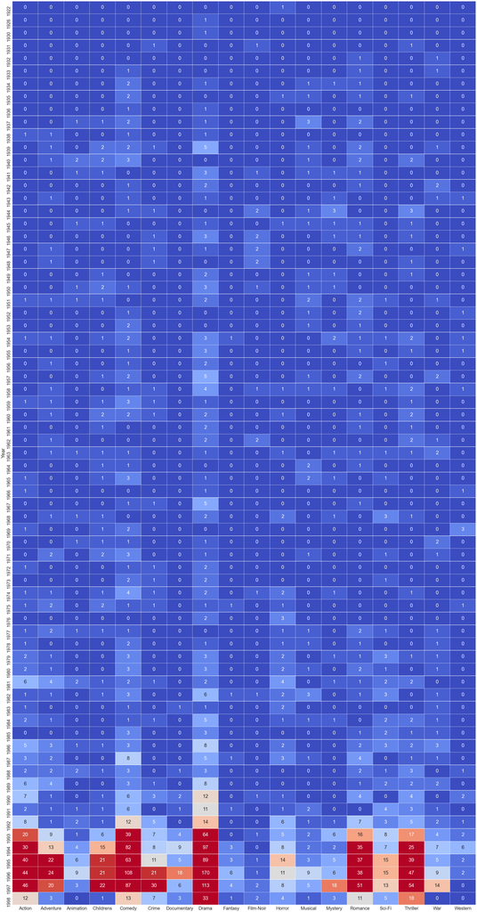

```python
plt.figure(figsize=(50,100))
sns.set(font_scale=2.5)
sns.heatmap(data=item7, annot=True, cmap='coolwarm', robust=True, fmt='.0f', linewidths=0.5, cbar=False, annot_kws={'size':30});
```

### 9. Find the top 25 movies according to average ratings such that each movie has number of ratings more than 100 - 10 marks

Hint :

1. First find the movies that have more than 100 ratings(use merge, groupby and count). Extract the movie titles in a list.
2. Find the average rating of all the movies and sort them in the descending order. You will have to use the .merge() function to reach to a data set through which you can get the names and the average rating.
3. Use isin(list obtained from 1) to filter out the movies which have more than 100 ratings.

Note: This question will need you to research about groupby and apply your findings. You can find more on groupby on https://realpython.com/pandas-groupby/.

```python
item8 = pd.merge(data, item, how='left', on='movie id')
#item8
```

```python
item8.info()
```

```
<class 'pandas.core.frame.DataFrame'>
Int64Index: 100000 entries, 0 to 99999
Data columns (total 25 columns):
 #   Column        Non-Null Count   Dtype
---  ------        --------------   -----
 0   user id       100000 non-null  int64
 1   movie id      100000 non-null  int64
 2   rating        100000 non-null  int64
 3   timestamp     100000 non-null  int64
 4   movie title   99991 non-null   object
 5   release date  99991 non-null   object
 6   unknown       99991 non-null   float64
 7   Action        99991 non-null   float64
 8   Adventure     99991 non-null   float64
 9   Animation     99991 non-null   float64
```

[output cut: 17 more lines]

```python
item9 = item8.groupby(['movie id']).count()
item9.head(15)
```

| movie id | user id | rating | timestamp | movie title | release date | unknown | Action | Adventure | Animation | Childrens | ... | Fantasy | Film-Noir | Horror | Musical | Mystery | Romance | Sci-Fi | Thriller | War | Western |
| --- | --- | --- | --- | --- | --- | --- | --- | --- | --- | --- | --- | --- | --- | --- | --- | --- | --- | --- | --- | --- | --- |
| 1 | 452 | 452 | 452 | 452 | 452 | 452 | 452 | 452 | 452 | 452 | ... | 452 | 452 | 452 | 452 | 452 | 452 | 452 | 452 | 452 | 452 |
| 2 | 131 | 131 | 131 | 131 | 131 | 131 | 131 | 131 | 131 | 131 | ... | 131 | 131 | 131 | 131 | 131 | 131 | 131 | 131 | 131 | 131 |
| 3 | 90 | 90 | 90 | 90 | 90 | 90 | 90 | 90 | 90 | 90 | ... | 90 | 90 | 90 | 90 | 90 | 90 | 90 | 90 | 90 | 90 |
| 4 | 209 | 209 | 209 | 209 | 209 | 209 | 209 | 209 | 209 | 209 | ... | 209 | 209 | 209 | 209 | 209 | 209 | 209 | 209 | 209 | 209 |
| 5 | 86 | 86 | 86 | 86 | 86 | 86 | 86 | 86 | 86 | 86 | ... | 86 | 86 | 86 | 86 | 86 | 86 | 86 | 86 | 86 | 86 |
| 6 | 26 | 26 | 26 | 26 | 26 | 26 | 26 | 26 | 26 | 26 | ... | 26 | 26 | 26 | 26 | 26 | 26 | 26 | 26 | 26 | 26 |
| 7 | 392 | 392 | 392 | 392 | 392 | 392 | 392 | 392 | 392 | 392 | ... | 392 | 392 | 392 | 392 | 392 | 392 | 392 | 392 | 392 | 392 |
| 8 | 219 | 219 | 219 | 219 | 219 | 219 | 219 | 219 | 219 | 219 | ... | 219 | 219 | 219 | 219 | 219 | 219 | 219 | 219 | 219 | 219 |
| 9 | 299 | 299 | 299 | 299 | 299 | 299 | 299 | 299 | 299 | 299 | ... | 299 | 299 | 299 | 299 | 299 | 299 | 299 | 299 | 299 | 299 |
| 10 | 89 | 89 | 89 | 89 | 89 | 89 | 89 | 89 | 89 | 89 | ... | 89 | 89 | 89 | 89 | 89 | 89 | 89 | 89 | 89 | 89 |
| 11 | 236 | 236 | 236 | 236 | 236 | 236 | 236 | 236 | 236 | 236 | ... | 236 | 236 | 236 | 236 | 236 | 236 | 236 | 236 | 236 | 236 |
| 12 | 267 | 267 | 267 | 267 | 267 | 267 | 267 | 267 | 267 | 267 | ... | 267 | 267 | 267 | 267 | 267 | 267 | 267 | 267 | 267 | 267 |
| 13 | 184 | 184 | 184 | 184 | 184 | 184 | 184 | 184 | 184 | 184 | ... | 184 | 184 | 184 | 184 | 184 | 184 | 184 | 184 | 184 | 184 |
| 14 | 183 | 183 | 183 | 183 | 183 | 183 | 183 | 183 | 183 | 183 | ... | 183 | 183 | 183 | 183 | 183 | 183 | 183 | 183 | 183 | 183 |
| 15 | 293 | 293 | 293 | 293 | 293 | 293 | 293 | 293 | 293 | 293 | ... | 293 | 293 | 293 | 293 | 293 | 293 | 293 | 293 | 293 | 293 |

15 rows × 24 columns

```python
item9.info()
```

```
<class 'pandas.core.frame.DataFrame'>
Int64Index: 1682 entries, 1 to 1682
Data columns (total 24 columns):
 #   Column        Non-Null Count  Dtype
---  ------        --------------  -----
 0   user id       1682 non-null   int64
 1   rating        1682 non-null   int64
 2   timestamp     1682 non-null   int64
 3   movie title   1682 non-null   int64
 4   release date  1682 non-null   int64
 5   unknown       1682 non-null   int64
 6   Action        1682 non-null   int64
 7   Adventure     1682 non-null   int64
 8   Animation     1682 non-null   int64
 9   Childrens     1682 non-null   int64
```

[output cut: 16 more lines]

```python
item9.sort_values(by=['rating'], ascending=False, inplace=True)
#item9
```

```python
item9.reset_index(inplace=True)
```

```python
#item9
```

```python
moviesratedGT100 = item9[['movie id', 'rating', 'movie title']].where((item9['rating'] ) > 100 ).dropna()
```

```python
moviesratedGT100.info()
```

```
<class 'pandas.core.frame.DataFrame'>
Int64Index: 334 entries, 0 to 333
Data columns (total 3 columns):
 #   Column       Non-Null Count  Dtype
---  ------       --------------  -----
 0   movie id     334 non-null    float64
 1   rating       334 non-null    float64
 2   movie title  334 non-null    float64
dtypes: float64(3)
memory usage: 10.4 KB
```

```python
# moviesratedGT100
```

### Find movie ratings total for each movie

```python
movie_rating = data[['movie id' , 'rating']]
#movie_rating
```

```python
movie_rating.info()
```

```
<class 'pandas.core.frame.DataFrame'>
RangeIndex: 100000 entries, 0 to 99999
Data columns (total 2 columns):
 #   Column    Non-Null Count   Dtype
---  ------    --------------   -----
 0   movie id  100000 non-null  int64
 1   rating    100000 non-null  int64
dtypes: int64(2)
memory usage: 1.5 MB
```

```python
movie_rating  = movie_rating.groupby(['movie id']).sum()
```

```python
movie_rating.info()
```

```
<class 'pandas.core.frame.DataFrame'>
Int64Index: 1682 entries, 1 to 1682
Data columns (total 1 columns):
 #   Column  Non-Null Count  Dtype
---  ------  --------------  -----
 0   rating  1682 non-null   int64
dtypes: int64(1)
memory usage: 26.3 KB
```

```python
movie_rating.reset_index(inplace = True)
```

```python
# movie_rating
```

```python
movie_count_A = data.groupby('movie id')['rating'].count()
```

```python
# movie_count_A
```

```python
movie_rating_count = movie_rating.merge(movie_count_A, how='inner' , on='movie id')
```

```python
#movie_rating_count
```

```python
movie_rating_count.rename(columns={'rating_x' : 'rating_sum' , 'rating_y' : 'rating_count'} , inplace = True)
```

```python
# movie_rating_count
```

```python
movie_rating_count['av rating'] = movie_rating_count.apply( lambda row: row.rating_sum / (row.rating_count), axis =1  )
```

```python
#movie_rating_count
```

## We have av rating with movie id in df movie_rating_count. ALso have count > 100 movies rated in moviesratedGT100

```python
#movie_rating_count
```

```python
#moviesratedGT100
```

```python
top_rated_movies = moviesratedGT100.merge( movie_rating_count, how='inner', on= 'movie id')
```

```python
#top_rated_movies
```

### We can just use movie_rating_count since it has av rating and rating_count. We merge with item , which has movie id & Title

```python
#item
```

```python
top_rated_movies_countGT100 = moviesratedGT100.merge( movie_rating_count, how='inner', on= 'movie id')
```

```python
#top_rated_movies_countGT100
```

```python
top_rated_25_movies_countGT100 = top_rated_movies_countGT100.sort_values( by='av rating' ,ascending=False)
```

```python
#top_rated_25_movies_countGT100
```

```python
top_rated_25_movies_countGT100 = top_rated_25_movies_countGT100.head(25)
```

```python
#top_rated_25_movies_countGT100
```

```python
top_rated_movies_titles = top_rated_25_movies_countGT100.merge(item, how='inner', on= 'movie id')
```

```python
top_rated_movies_titles
```

|  | movie id | rating | movie title_x | rating_sum | rating_count | av rating | movie title_y | release date | unknown | Action | ... | Fantasy | Film-Noir | Horror | Musical | Mystery | Romance | Sci-Fi | Thriller | War | Western |
| --- | --- | --- | --- | --- | --- | --- | --- | --- | --- | --- | --- | --- | --- | --- | --- | --- | --- | --- | --- | --- | --- |
| 0 | 408.0 | 112.0 | 112.0 | 503 | 112 | 4.491071 | Close Shave, A | 28-Apr-1996 | 0 | 0 | ... | 0 | 0 | 0 | 0 | 0 | 0 | 0 | 1 | 0 | 0 |
| 1 | 318.0 | 298.0 | 298.0 | 1331 | 298 | 4.466443 | Schindler's List | 01-Jan-1993 | 0 | 0 | ... | 0 | 0 | 0 | 0 | 0 | 0 | 0 | 0 | 1 | 0 |
| 2 | 169.0 | 118.0 | 118.0 | 527 | 118 | 4.466102 | Wrong Trousers, The | 01-Jan-1993 | 0 | 0 | ... | 0 | 0 | 0 | 0 | 0 | 0 | 0 | 0 | 0 | 0 |
| 3 | 483.0 | 243.0 | 243.0 | 1083 | 243 | 4.456790 | Casablanca | 01-Jan-1942 | 0 | 0 | ... | 0 | 0 | 0 | 0 | 0 | 1 | 0 | 0 | 1 | 0 |
| 4 | 64.0 | 283.0 | 283.0 | 1258 | 283 | 4.445230 | Shawshank Redemption, The | 01-Jan-1994 | 0 | 0 | ... | 0 | 0 | 0 | 0 | 0 | 0 | 0 | 0 | 0 | 0 |
| 5 | 603.0 | 209.0 | 209.0 | 917 | 209 | 4.387560 | Rear Window | 01-Jan-1954 | 0 | 0 | ... | 0 | 0 | 0 | 0 | 1 | 0 | 0 | 1 | 0 | 0 |
| 6 | 12.0 | 267.0 | 267.0 | 1171 | 267 | 4.385768 | Usual Suspects, The | 14-Aug-1995 | 0 | 0 | ... | 0 | 0 | 0 | 0 | 0 | 0 | 0 | 1 | 0 | 0 |
| 7 | 50.0 | 583.0 | 583.0 | 2541 | 583 | 4.358491 | Star Wars | 01-Jan-1977 | 0 | 1 | ... | 0 | 0 | 0 | 0 | 0 | 1 | 1 | 0 | 1 | 0 |
| 8 | 178.0 | 125.0 | 125.0 | 543 | 125 | 4.344000 | 12 Angry Men | 01-Jan-1957 | 0 | 0 | ... | 0 | 0 | 0 | 0 | 0 | 0 | 0 | 0 | 0 | 0 |
| 9 | 134.0 | 198.0 | 198.0 | 850 | 198 | 4.292929 | Citizen Kane | 01-Jan-1941 | 0 | 0 | ... | 0 | 0 | 0 | 0 | 0 | 0 | 0 | 0 | 0 | 0 |
| 10 | 427.0 | 219.0 | 219.0 | 940 | 219 | 4.292237 | To Kill a Mockingbird | 01-Jan-1962 | 0 | 0 | ... | 0 | 0 | 0 | 0 | 0 | 0 | 0 | 0 | 0 | 0 |
| 11 | 357.0 | 264.0 | 264.0 | 1133 | 264 | 4.291667 | One Flew Over the Cuckoo's Nest | 01-Jan-1975 | 0 | 0 | ... | 0 | 0 | 0 | 0 | 0 | 0 | 0 | 0 | 0 | 0 |
| 12 | 98.0 | 390.0 | 390.0 | 1673 | 390 | 4.289744 | Silence of the Lambs, The | 01-Jan-1991 | 0 | 0 | ... | 0 | 0 | 0 | 0 | 0 | 0 | 0 | 1 | 0 | 0 |
| 13 | 480.0 | 179.0 | 179.0 | 767 | 179 | 4.284916 | North by Northwest | 01-Jan-1959 | 0 | 0 | ... | 0 | 0 | 0 | 0 | 0 | 0 | 0 | 1 | 0 | 0 |
| 14 | 127.0 | 413.0 | 413.0 | 1769 | 413 | 4.283293 | Godfather, The | 01-Jan-1972 | 0 | 1 | ... | 0 | 0 | 0 | 0 | 0 | 0 | 0 | 0 | 0 | 0 |
| 15 | 285.0 | 162.0 | 162.0 | 691 | 162 | 4.265432 | Secrets & Lies | 04-Oct-1996 | 0 | 0 | ... | 0 | 0 | 0 | 0 | 0 | 0 | 0 | 0 | 0 | 0 |
| 16 | 272.0 | 198.0 | 198.0 | 844 | 198 | 4.262626 | Good Will Hunting | 01-Jan-1997 | 0 | 0 | ... | 0 | 0 | 0 | 0 | 0 | 0 | 0 | 0 | 0 | 0 |
| 17 | 657.0 | 131.0 | 131.0 | 558 | 131 | 4.259542 | Manchurian Candidate, The | 01-Jan-1962 | 0 | 0 | ... | 0 | 1 | 0 | 0 | 0 | 0 | 0 | 1 | 0 | 0 |
| 18 | 474.0 | 194.0 | 194.0 | 825 | 194 | 4.252577 | Dr. Strangelove or: How I Learned to Stop Worr... | 01-Jan-1963 | 0 | 0 | ... | 0 | 0 | 0 | 0 | 0 | 0 | 1 | 0 | 1 | 0 |
| 19 | 174.0 | 420.0 | 420.0 | 1786 | 420 | 4.252381 | Raiders of the Lost Ark | 01-Jan-1981 | 0 | 1 | ... | 0 | 0 | 0 | 0 | 0 | 0 | 0 | 0 | 0 | 0 |
| 20 | 479.0 | 179.0 | 179.0 | 761 | 179 | 4.251397 | Vertigo | 01-Jan-1958 | 0 | 0 | ... | 0 | 0 | 0 | 0 | 1 | 0 | 0 | 1 | 0 | 0 |
| 21 | 313.0 | 350.0 | 350.0 | 1486 | 350 | 4.245714 | Titanic | 01-Jan-1997 | 0 | 1 | ... | 0 | 0 | 0 | 0 | 0 | 1 | 0 | 0 | 0 | 0 |
| 22 | 511.0 | 173.0 | 173.0 | 732 | 173 | 4.231214 | Lawrence of Arabia | 01-Jan-1962 | 0 | 0 | ... | 0 | 0 | 0 | 0 | 0 | 0 | 0 | 0 | 1 | 0 |
| 23 | 484.0 | 138.0 | 138.0 | 581 | 138 | 4.210145 | Maltese Falcon, The | 01-Jan-1941 | 0 | 0 | ... | 0 | 1 | 0 | 0 | 1 | 0 | 0 | 0 | 0 | 0 |
| 24 | 172.0 | 367.0 | 367.0 | 1543 | 367 | 4.204360 | Empire Strikes Back, The | 01-Jan-1980 | 0 | 1 | ... | 0 | 0 | 0 | 0 | 0 | 1 | 1 | 0 | 1 | 0 |

25 rows × 27 columns

### Top rated 25 movies with more than 100 review

```python
print(' List of top 25 movies with best ratings , where each movie is rated more than 100 time is :\n' ,top_rated_movies_titles['movie title_y'])
```

```
 List of top 25 movies with best ratings , where each movie is rated more than 100 time is :
 0                                       Close Shave, A
1                                     Schindler's List
2                                  Wrong Trousers, The
3                                           Casablanca
4                            Shawshank Redemption, The
5                                          Rear Window
6                                  Usual Suspects, The
7                                            Star Wars
8                                         12 Angry Men
9                                         Citizen Kane
10                               To Kill a Mockingbird
11                     One Flew Over the Cuckoo's Nest
12                           Silence of the Lambs, The
13                                  North by Northwest
14                                      Godfather, The
15                                      Secrets & Lies
16                                   Good Will Hunting
17                           Manchurian Candidate, The
18    Dr. Strangelove or: How I Learned to Stop Worr...
19                             Raiders of the Lost Ark
20                                             Vertigo
21                                             Titanic
22                                  Lawrence of Arabia
23                                 Maltese Falcon, The
24                            Empire Strikes Back, The
Name: movie title_y, dtype: object
```

### 10. See gender distribution across different genres check for the validity of the below statements - 10 marks

- Men watch more drama than women
- Women watch more Sci-Fi than men
- Men watch more Romance than women
1. There is no need to conduct statistical tests around this. Just compare the percentages and comment on the validity of the above statements.
2. you might want ot use the .sum(), .div() function here.
3. Use number of ratings to validate the numbers. For example, if out of 4000 ratings received by women, 3000 are for drama, we will assume that 75% of the women watch drama.

```python
item_drama = item[['movie id', 'Drama']]
```

```python
#item_drama
```

```python
item_drama_Y = item_drama.where(item_drama['Drama'] == 1 ).dropna()
```

```python
#item_drama_Y
```

```python
item_drama_Y_user = data.merge( item_drama_Y , how='inner', on='movie id')
```

```python
#item_drama_Y_user
```

```python
## Test with one movie id
item_drama_Y_user.where(item_drama_Y_user['movie id'] == 51).dropna()
```

|  | user id | movie id | rating | timestamp | Drama |
| --- | --- | --- | --- | --- | --- |
| 0 | 244.0 | 51.0 | 2.0 | 880606923.0 | 1.0 |
| 1 | 85.0 | 51.0 | 2.0 | 879454782.0 | 1.0 |
| 2 | 201.0 | 51.0 | 2.0 | 884140751.0 | 1.0 |
| 3 | 198.0 | 51.0 | 3.0 | 884208455.0 | 1.0 |
| 4 | 330.0 | 51.0 | 5.0 | 876546753.0 | 1.0 |
| 5 | 194.0 | 51.0 | 4.0 | 879549793.0 | 1.0 |
| 6 | 1.0 | 51.0 | 4.0 | 878543275.0 | 1.0 |
| 7 | 230.0 | 51.0 | 4.0 | 880484937.0 | 1.0 |
| 8 | 236.0 | 51.0 | 5.0 | 890116709.0 | 1.0 |
| 9 | 56.0 | 51.0 | 3.0 | 892677186.0 | 1.0 |
| 10 | 152.0 | 51.0 | 4.0 | 882476486.0 | 1.0 |
| 11 | 256.0 | 51.0 | 4.0 | 882165135.0 | 1.0 |
| 12 | 16.0 | 51.0 | 4.0 | 877726390.0 | 1.0 |
| 13 | 137.0 | 51.0 | 1.0 | 881433605.0 | 1.0 |
| 14 | 145.0 | 51.0 | 3.0 | 875272786.0 | 1.0 |
| 15 | 345.0 | 51.0 | 5.0 | 884993744.0 | 1.0 |
| 16 | 224.0 | 51.0 | 4.0 | 888104457.0 | 1.0 |
| 17 | 151.0 | 51.0 | 4.0 | 879543055.0 | 1.0 |
| 18 | 72.0 | 51.0 | 4.0 | 880036946.0 | 1.0 |
| 19 | 416.0 | 51.0 | 5.0 | 893212895.0 | 1.0 |
| 20 | 11.0 | 51.0 | 4.0 | 891906439.0 | 1.0 |
| 21 | 43.0 | 51.0 | 1.0 | 883956562.0 | 1.0 |
| 22 | 13.0 | 51.0 | 3.0 | 882399419.0 | 1.0 |
| 23 | 59.0 | 51.0 | 5.0 | 888206095.0 | 1.0 |
| 24 | 454.0 | 51.0 | 2.0 | 888267158.0 | 1.0 |
| 25 | 269.0 | 51.0 | 2.0 | 891451111.0 | 1.0 |
| 26 | 468.0 | 51.0 | 3.0 | 875293386.0 | 1.0 |
| 27 | 405.0 | 51.0 | 1.0 | 885546577.0 | 1.0 |
| 28 | 561.0 | 51.0 | 3.0 | 885810834.0 | 1.0 |
| 29 | 504.0 | 51.0 | 4.0 | 887839260.0 | 1.0 |

[output cut: 51 more lines]

```python
item_drama_Y_user_profile = item_drama_Y_user.merge( user , how ='inner', on='user id')
```

```python
#item_drama_Y_user_profile
```

```python
#item_drama_Y_user_profile.groupby(item_drama_Y_user_profile['gender']).count()
item_drama_Y_user_profile_all = item_drama_Y_user_profile.groupby(['gender']).count()
```

```python
item_drama_Y_user_profile_MF = item_drama_Y_user_profile_all['user id']
```

```python
item_drama_Y_user_profile_MF
```

```
gender
F    11008
M    28887
Name: user id, dtype: int64
```

```python
## access series value for F
item_drama_Y_user_profile_MF.F
```

```
11008
```

### Answer to question - Gender which watches more movies of the genre Drama

```python
print( 'Gender which watches more movies of the genre Drama is : \n')
if ( item_drama_Y_user_profile_MF.F ) > ( item_drama_Y_user_profile_MF.M ):
    print ( '\033[1m Females watch more movies of the genre Drama \033[0m')
elif ( item_drama_Y_user_profile_MF.M ) > ( item_drama_Y_user_profile_MF.F ):
    print ( '\033[1m Males watch more movies of the genre Drama \033[0m')
else:
    print ( '\033[m1 Males & Females watch same number of movies, of the genre Drama \033[0m')
```

```
Gender which watches more movies of the genre Drama is :

 Males watch more movies of the genre Drama
```

### women watch more sci-fi than men - Section

```python
item_scifi = item[['movie id', 'Sci-Fi']]
```

```python
#item_scifi
```

```python
item_scifi_Y = item_scifi.where(item_scifi['Sci-Fi'] == 1 ).dropna()
```

```python
#item_scifi_Y
```

```python
item_scifi_Y_user = data.merge( item_scifi_Y , how='inner', on='movie id')
```

```python
#item_scifi_Y_user
```

```python
## Test with one movie id
item_scifi_Y_user.where(item_scifi_Y_user['movie id'] == 1159).dropna()
```

|  | user id | movie id | rating | timestamp | Sci-Fi |
| --- | --- | --- | --- | --- | --- |
| 12716 | 385.0 | 1159.0 | 4.0 | 885245956.0 | 1.0 |
| 12717 | 183.0 | 1159.0 | 3.0 | 891479702.0 | 1.0 |
| 12718 | 405.0 | 1159.0 | 1.0 | 885549407.0 | 1.0 |
| 12719 | 758.0 | 1159.0 | 5.0 | 881974639.0 | 1.0 |
| 12720 | 747.0 | 1159.0 | 2.0 | 888639685.0 | 1.0 |
| 12721 | 409.0 | 1159.0 | 2.0 | 881109019.0 | 1.0 |
| 12722 | 543.0 | 1159.0 | 5.0 | 875665787.0 | 1.0 |
| 12723 | 867.0 | 1159.0 | 5.0 | 880078796.0 | 1.0 |
| 12724 | 645.0 | 1159.0 | 4.0 | 892054632.0 | 1.0 |
| 12725 | 76.0 | 1159.0 | 3.0 | 882606623.0 | 1.0 |
| 12726 | 358.0 | 1159.0 | 5.0 | 891269617.0 | 1.0 |

```python
item_scifi_Y_user_profile = item_scifi_Y_user.merge( user , how ='inner', on='user id')
```

```python
#item_scifi_Y_user_profile
```

```python
item_scifi_Y_user_profile_all = item_scifi_Y_user_profile.groupby(['gender']).count()
```

```python
item_scifi_Y_user_profile_all
```

| gender | user id | movie id | rating | timestamp | Sci-Fi | age | occupation | zip code |
| --- | --- | --- | --- | --- | --- | --- | --- | --- |
| F | 2629 | 2629 | 2629 | 2629 | 2629 | 2629 | 2629 | 2629 |
| M | 10101 | 10101 | 10101 | 10101 | 10101 | 10101 | 10101 | 10101 |

```python
item_scifi_Y_user_profile_MF = item_scifi_Y_user_profile_all['user id']
```

```python
item_scifi_Y_user_profile_MF
```

```
gender
F     2629
M    10101
Name: user id, dtype: int64
```

```python
item_scifi_Y_user_profile_MF.F
```

```
2629
```

### Answer to question - Gender which watches more movies of the genre Sci-Fi

```python
print(' Which gender watched more movies of the genre Sci-Fi? \n')
if ( item_scifi_Y_user_profile_MF.F ) > ( item_scifi_Y_user_profile_MF.M ):
    print ( '\033[1m Females watch more movies of the genre Sci-Fi\033[0m')
elif ( item_scifi_Y_user_profile_MF.M ) > ( item_scifi_Y_user_profile_MF.F ):
    print ( '\033[1m Males watch more movies of the genre Sci-Fi \033[0m')
else:
    print ( '\033[1m Males & Females watch same number of movies, of the genre Sci-Fi\033[0m')
```

```
 Which gender watched more movies of the genre Sci-Fi?

 Males watch more movies of the genre Sci-Fi
```

### Men watch more Romance than women Section

```python
item_romance = item[['movie id', 'Romance']]
```

```python
#item_romance
```

```python
item_romance_Y = item_romance.where(item_romance['Romance'] == 1 ).dropna()
```

```python
#item_romance_Y
```

```python
item_romance_Y_user = data.merge( item_romance_Y , how='inner', on='movie id')
```

```python
#item_romance_Y_user
```

```python
## Check with one movie id
item_romance_Y_user.where(item_romance_Y_user['movie id'] == 1050).dropna().count()
```

```
user id      43
movie id     43
rating       43
timestamp    43
Romance      43
dtype: int64
```

```python
item_romance_Y_user_profile = item_romance_Y_user.merge( user , how ='inner', on='user id')
```

```python
#item_romance_Y_user_profile
```

```python
item_romance_Y_user_profile_all = item_romance_Y_user_profile.groupby(['gender']).count()
```

```python
item_romance_Y_user_profile_all
```

| gender | user id | movie id | rating | timestamp | Romance | age | occupation | zip code |
| --- | --- | --- | --- | --- | --- | --- | --- | --- |
| F | 5858 | 5858 | 5858 | 5858 | 5858 | 5858 | 5858 | 5858 |
| M | 13603 | 13603 | 13603 | 13603 | 13603 | 13603 | 13603 | 13603 |

```python
item_romance_Y_user_profile_MF = item_romance_Y_user_profile_all['user id']
```

```python
item_romance_Y_user_profile_MF
```

```
gender
F     5858
M    13603
Name: user id, dtype: int64
```

```python
item_romance_Y_user_profile_MF.F
```

```
5858
```

#### Answer to question - Gender which watches more movies of the genre Romance

```python
print('\033[1m Answer to question - Gender which watches more movies of the genre Romance\033[0m \n')
if ( item_romance_Y_user_profile_MF.F ) > ( item_romance_Y_user_profile_MF.M ):
    print ( '\033[1mFemales watch more movies of the genre Romance \033[0m')
elif ( item_romance_Y_user_profile_MF.M ) > ( item_romance_Y_user_profile_MF.F ):
    print ( '\033[1mMales watch more movies of the genre Romance \033[0m')
else:
    print ( '\033[1mMales & Females watch same number of movies, of the genre Romance \033[0m')
```

```
 Answer to question - Gender which watches more movies of the genre Romance

Males watch more movies of the genre Romance
```